# Predicting Student Performance from Survey Data

Joseph Kintzel, Bernard Mcshea and Vishal Kapoor

May 4, 2016

## Project Introduction

Seeking efficiency in the pursuit of education is a perpetual goal, We wish to investigate the effects of extracurricular activities and family dynamics on a student’s GPA score. First, we recognize there are many factors that can influence a student’s GPA that may not be causation and must investigate cautiously. The goal would be to find an optimal combination of factors that could predict GPA of a student and hopefully with this information we could recommend a student add or drop activities to help optimize their projected GPA.

A secondary use would be for a screening tool for colleges to determine which students would perform the best. Using a predictive model or machine learning to remove some human bias.

We have used a student survey with 745 sample observations from a school but did not get the full population. This sample can be considered a very large random sample. Each student’s GPA should be relatively independent. Typically the grades are not directly curved, just individual tests.

## Data Wrangling starts

We first read in the CSV file and do some mild data wrangling.

```r
# Read in the data.
survey <- read_csv("giftcarddataMASTER2.csv")

tab <- x <- survey #Copying into tab required at later stage

# The full list of variables:
# age,gender,job,club,sport,band,game_hrs,GPA,siblings,friends,books,meals,iphone,songs,absent,romance,study,mother,father,parents

x <- x %>% filter(!is.na(age)) %>% filter(!is.na(gender)) %>% filter(!is.na(job)) %>% filter(!is.na(club)) %>% filter(!is.na(sport)) %>% filter(!is.na(band)) %>% filter(!is.na(game_hrs)) %>% filter(!is.na(GPA)) %>% filter(!is.na(siblings)) %>% filter(!is.na(friends)) %>% filter(!is.na(books)) %>% filter(!is.na(books)) %>% filter(!is.na(meals)) %>% filter(!is.na(iphone)) %>% filter(!is.na(songs)) %>% filter(!is.na(absent)) %>% filter(!is.na(romance)) %>% filter(!is.na(study)) %>% filter(!is.na(mother)) %>% filter(!is.na(father)) %>% filter(!is.na(parents))

x <- x %>% filter(gender != "Y")
```

## Including Plots.

From our data wrangling, we know that the data is categorical, with a large portion being binary. We quickly make a few plots to see if the data hints at any possible trends. Since we have many binary variables we start with some boxplots then move to scatterplots for the remaining variables.

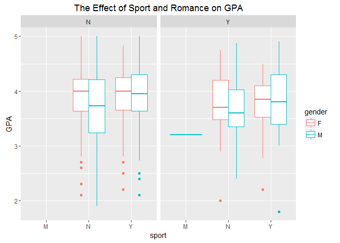

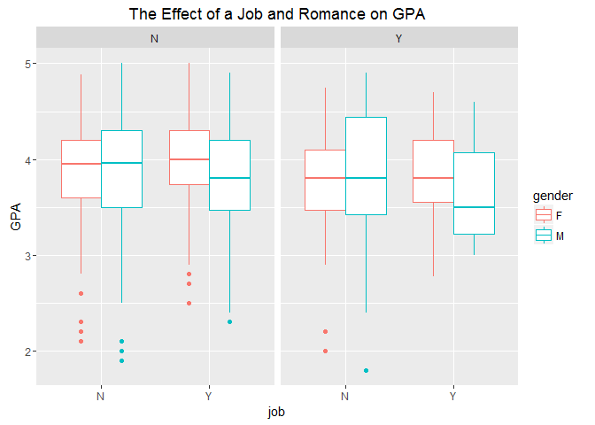

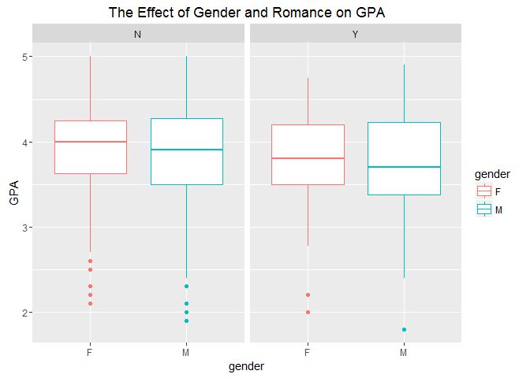

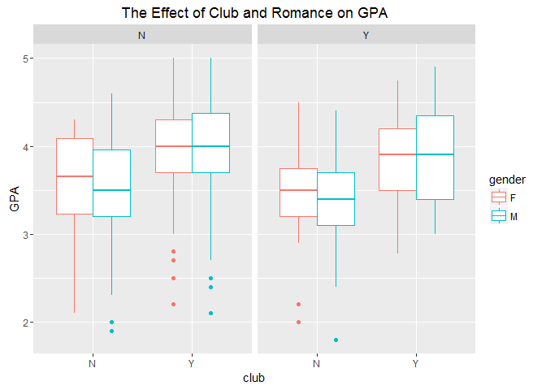

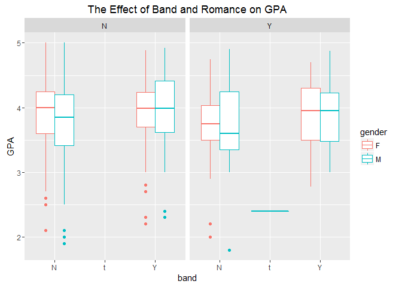

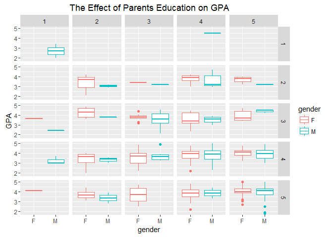

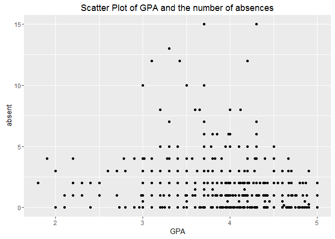

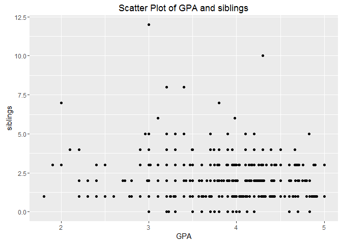

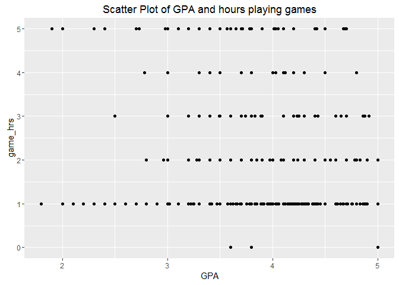

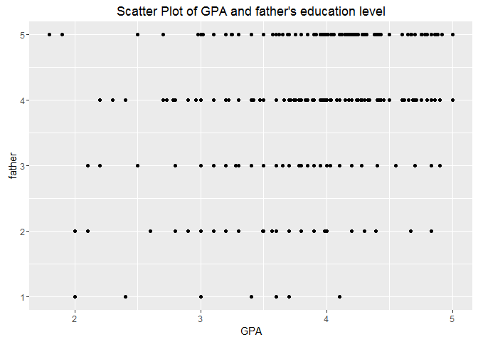

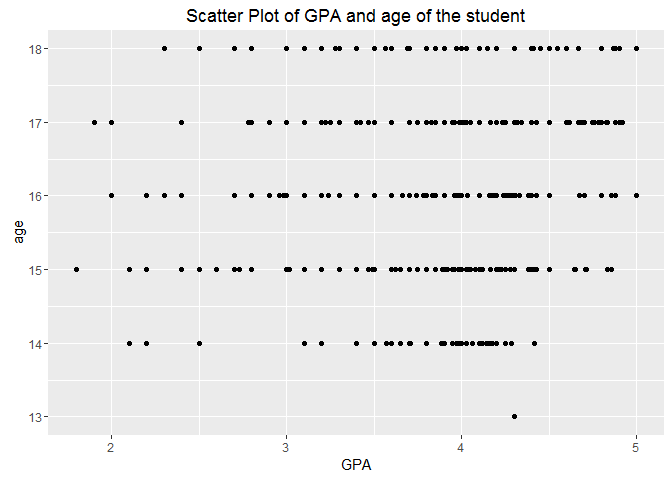

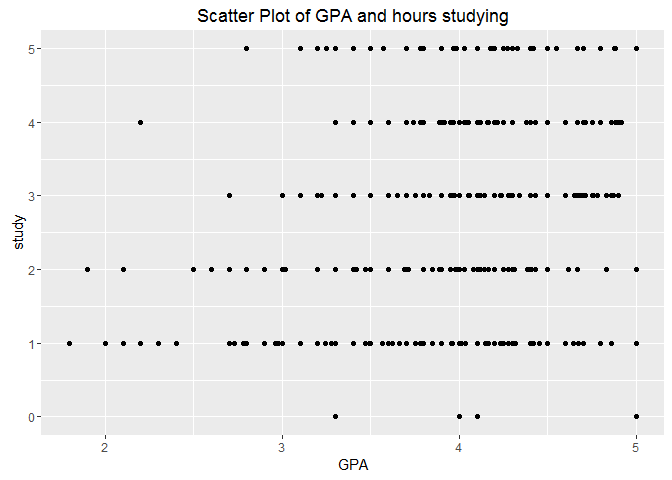

## Boxplots and Scatterplots

First considering the boxplots, we can see there might be an effect between; sport, job, club, and band with respect to gender and romance. The first three scatter plots (absent, siblings, game_hrs) did not show a linear relationship. Looking at the relationships between GPA and fathers education, age, and study we can see a linear effect, however the data is highly categorical. - More Data wrangling

```r
x <- x %>% mutate(gender_bin = ifelse(gender == "F", 0, 1))

x <- x %>% mutate(job = ifelse(job == "N", 0, 1))
x <- x %>% mutate(club = ifelse(club == "N", 0, 1))

x <- x %>% mutate(sport = ifelse(sport == "N", 0, 1))
x <- x %>% mutate(band = ifelse(band == "N", 0, 1))

x <- x %>% mutate(iphone = ifelse(iphone == "N", 0, 1))
x <- x %>% mutate(romance = ifelse(romance == "N", 0, 1))

x <- x %>% mutate(parents = ifelse(parents == "M", 1, 0))
```

# Linear Regression

We know that the data is highly categorical, so we will keep an eye out for Linearity condition. We will try a few models. Then we will explore if the conditions of linear regression (Linearity, Zero Mean, Constant Variance, Independence and Random, and Normality) are met for the most promising models.

```r
# Just try a lot of factors at once and see what happens.
fit <- x %>% lm(GPA ~ gender_bin + romance + age + club + study , data = .)
summary(fit)
```

```
##
## Call:
## lm(formula = GPA ~ gender_bin + romance + age + club + study,
##     data = .)
##
## Residuals:
##     Min      1Q  Median      3Q     Max
## -1.6671 -0.3283  0.0414  0.3607  1.2958
##
## Coefficients:
##             Estimate Std. Error t value Pr(>|t|)
## (Intercept)  2.53535    0.30642   8.274 8.39e-16 ***
## gender_bin   0.03374    0.04341   0.777   0.4374
## romance     -0.09452    0.04986  -1.895   0.0585 .
## age          0.04591    0.01881   2.441   0.0149 *
## club         0.40051    0.05086   7.875 1.61e-14 ***
## study        0.10878    0.01626   6.689 5.14e-11 ***
## ---
## Signif. codes:  0 '***' 0.001 '**' 0.01 '*' 0.05 '.' 0.1 ' ' 1
##
## Residual standard error: 0.5136 on 600 degrees of freedom
## Multiple R-squared:  0.1886, Adjusted R-squared:  0.1818
## F-statistic: 27.89 on 5 and 600 DF,  p-value: < 2.2e-16
```

```r
fit <- x %>% lm(GPA ~ gender_bin + romance, data = .)
summary(fit)
```

```
##
## Call:
## lm(formula = GPA ~ gender_bin + romance, data = .)
##
## Residuals:
##      Min       1Q   Median       3Q      Max
## -1.95480 -0.35472  0.04528  0.37827  1.14528
##
## Coefficients:
##             Estimate Std. Error t value Pr(>|t|)
## (Intercept)  3.90476    0.03500 111.565   <2e-16 ***
## gender_bin  -0.05005    0.04605  -1.087   0.2775
## romance     -0.09992    0.05409  -1.847   0.0652 .
## ---
## Signif. codes:  0 '***' 0.001 '**' 0.01 '*' 0.05 '.' 0.1 ' ' 1
##
## Residual standard error: 0.5666 on 603 degrees of freedom
## Multiple R-squared:  0.007409,   Adjusted R-squared:  0.004116
## F-statistic:  2.25 on 2 and 603 DF,  p-value: 0.1062
```

```r
assess_linear_model <- function(fit) {

  plot(fit)

  #ggplot(fit, aes(sample = fit$residuals)) + stat_qq(aes(sample=fit$residuals)) + geom_abline(intercept = 0, slope = .5)

  #qqplot(resid(fit), predict(fit, newdata = x, type = "response"))
  #qqline(resid(fit))

  hist(resid(fit))

  # standardized residuals
  plot(predict(fit, newdata = x, type = "response"), resid(fit))
  abline(0,0)

}

fit <- x %>% lm(GPA ~ club + father + study + age + siblings + meals, data = .)
summary(fit)
```

```
##
## Call:
## lm(formula = GPA ~ club + father + study + age + siblings + meals,
##     data = .)
##
## Residuals:
##      Min       1Q   Median       3Q      Max
## -1.78913 -0.30865  0.01233  0.35199  1.18547
##
## Coefficients:
##             Estimate Std. Error t value Pr(>|t|)
## (Intercept)  1.96645    0.32022   6.141 1.50e-09 ***
## club         0.36497    0.04940   7.389 5.01e-13 ***
## father       0.12327    0.02328   5.296 1.66e-07 ***
## study        0.09593    0.01568   6.119 1.71e-09 ***
## age          0.05969    0.01849   3.228  0.00132 **
## siblings    -0.03340    0.01630  -2.048  0.04095 *
## meals       -0.01199    0.00409  -2.932  0.00349 **
## ---
## Signif. codes:  0 '***' 0.001 '**' 0.01 '*' 0.05 '.' 0.1 ' ' 1
##
## Residual standard error: 0.4985 on 599 degrees of freedom
## Multiple R-squared:  0.2368, Adjusted R-squared:  0.2292
## F-statistic: 30.98 on 6 and 599 DF,  p-value: < 2.2e-16
```

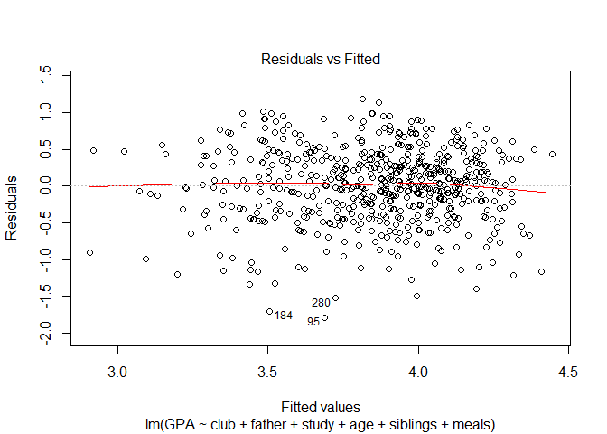

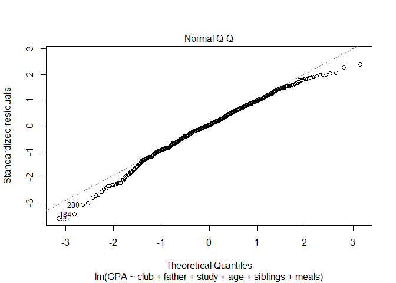

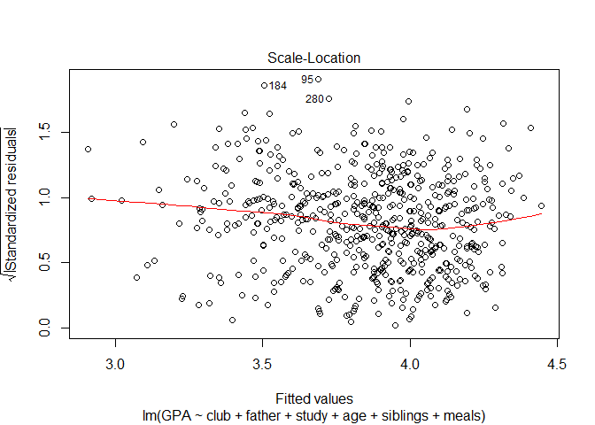

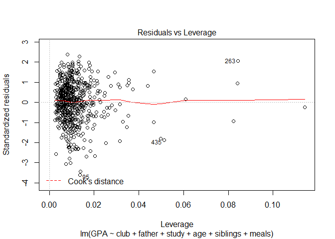

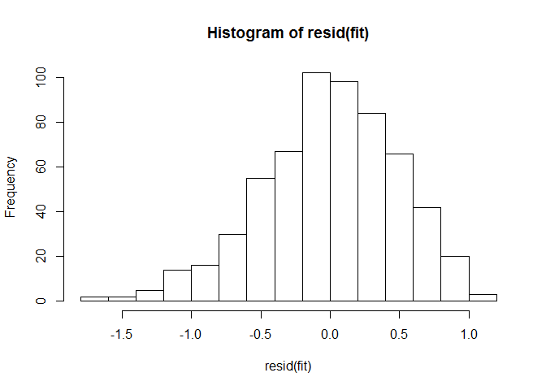

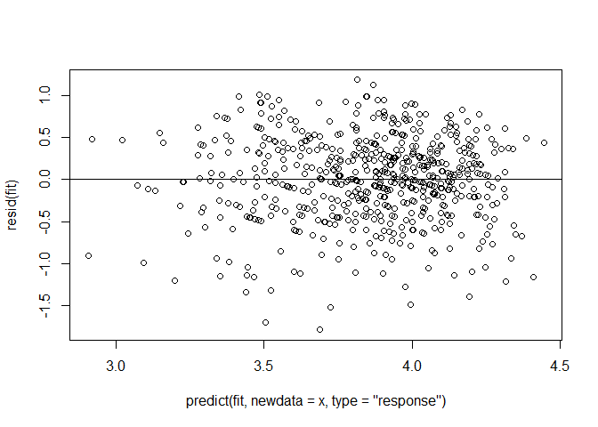

```r
assess_linear_model(fit)
```

# A good model and a closer look at our assumptions.

GPA ~ club + father + study + age + siblings + meals is an interesting model since all betas have a p-value less then 0.05 we can reject the null hypothesis in all cases. Thus each beta has significance. The R^2-Adjusted give us concern since it is only 0.2292 or 22.92%.

Lets take a moment and assess our assumptions for linear regression.

# Assumptions:

Linearity: The data is highly categorical as we saw with the box and scatter plots in the first section of data exploration.

Zero Mean: The distribution of the errors is centered at zero. We meet this assumption because we are using least squares regression.

Independence and Random: We can make the assumption of independence among our observations via the data collection methodology.

Normality: The Q-Q plot has tails however over all it looks pretty good. The histogram of the residual is approximately normal with slightly more values above zero.

Given our difficulty demonstrating linearity and the low R^2-adjusted of only 22.92% we will move to Logit regression.

Let us explore a few models to convince ourselves that we can not improve on R^2-adjusted of only 22.92%.

```r
# Good simple model.
fit <- x %>% lm(GPA ~ father + club + study, data = .)
summary(fit)
```

```
##
## Call:
## lm(formula = GPA ~ father + club + study, data = .)
##
## Residuals:
##      Min       1Q   Median       3Q      Max
## -1.72226 -0.29883  0.02746  0.33536  1.20157
##
## Coefficients:
##             Estimate Std. Error t value Pr(>|t|)
## (Intercept)  2.81026    0.10509  26.741  < 2e-16 ***
## father       0.12344    0.02353   5.246 2.16e-07 ***
## club         0.37099    0.04998   7.422 3.94e-13 ***
## study        0.09482    0.01580   6.001 3.38e-09 ***
## ---
## Signif. codes:  0 '***' 0.001 '**' 0.01 '*' 0.05 '.' 0.1 ' ' 1
##
## Residual standard error: 0.5055 on 602 degrees of freedom
## Multiple R-squared:  0.2113, Adjusted R-squared:  0.2074
## F-statistic: 53.76 on 3 and 602 DF,  p-value: < 2.2e-16
```

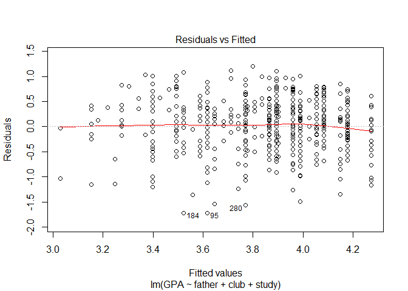

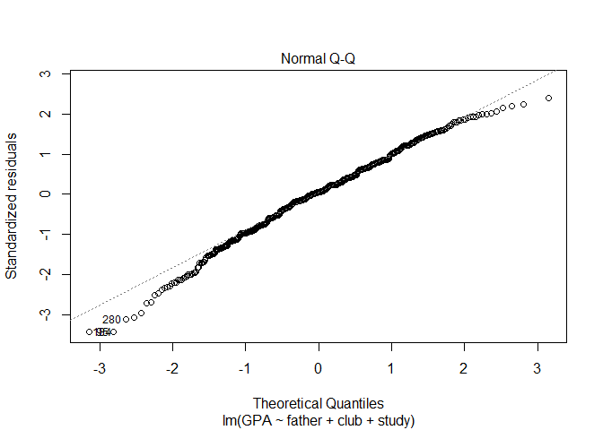

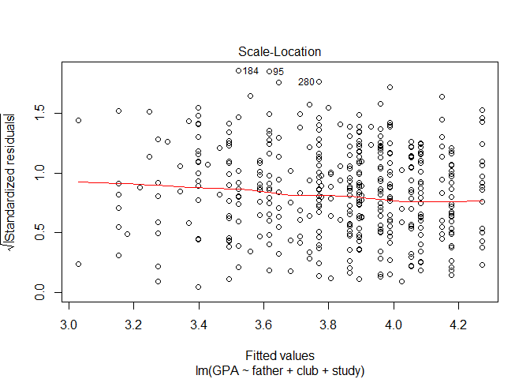

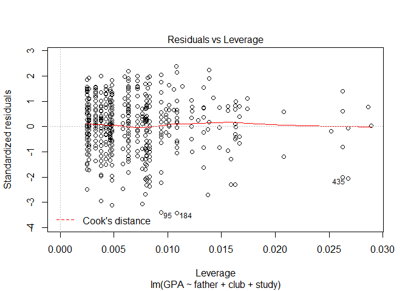

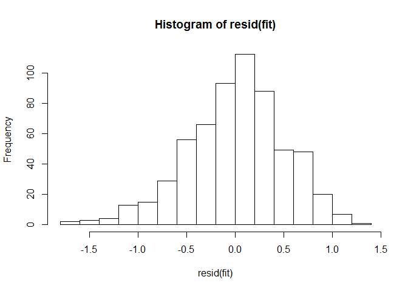

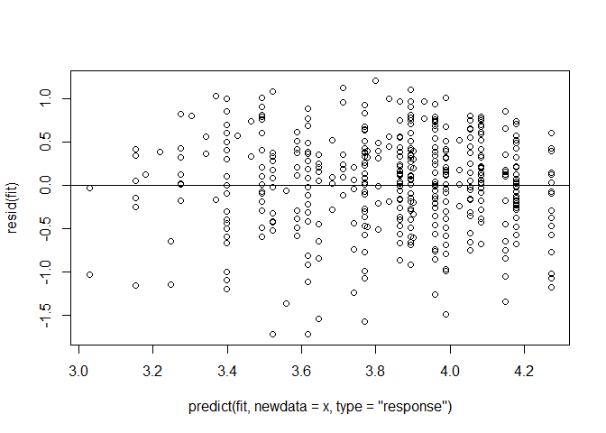

```r
assess_linear_model(fit)
```

The Normal Q-Q plot has tails, Constant Variance may be an issue, and the R^2-adjusted of 0.2074 lead us to abandon this model.

# Let’s try combining some variables

```r
x <- x %>% mutate(parents_education = mother + father)
x <- x %>% mutate(extra_curricular = band + club + sport)
x <- x %>% mutate(time_working = absent + study) # not a good combo I will work on this.
x <- x %>% mutate(friends_siblings = ifelse(friends == 1 & siblings == 1, 1, 0))
x <- x %>% mutate(female_romance = ifelse(gender == 0 & romance == 1, 1, 0))
x <- x %>% mutate(male_romance = ifelse(gender == 1 & romance == 1, 1, 0))


fit <- x %>% lm(GPA ~ parents_education + extra_curricular + time_working + friends_siblings + female_romance + male_romance, data = .)
summary(fit)
```

```
##
## Call:
## lm(formula = GPA ~ parents_education + extra_curricular + time_working +
##     friends_siblings + female_romance + male_romance, data = .)
##
## Residuals:
##      Min       1Q   Median       3Q      Max
## -2.06728 -0.31243  0.03028  0.33413  1.27727
##
## Coefficients: (2 not defined because of singularities)
##                   Estimate Std. Error t value Pr(>|t|)
## (Intercept)       2.718636   0.138226  19.668  < 2e-16 ***
## parents_education 0.094471   0.015941   5.926 5.22e-09 ***
## extra_curricular  0.160811   0.027207   5.911 5.72e-09 ***
## time_working      0.014373   0.005762   2.495   0.0129 *
## friends_siblings  0.111661   0.071720   1.557   0.1200
## female_romance          NA         NA      NA       NA
## male_romance            NA         NA      NA       NA
## ---
## Signif. codes:  0 '***' 0.001 '**' 0.01 '*' 0.05 '.' 0.1 ' ' 1
##
## Residual standard error: 0.5307 on 601 degrees of freedom
## Multiple R-squared:  0.1321, Adjusted R-squared:  0.1264
## F-statistic: 22.88 on 4 and 601 DF,  p-value: < 2.2e-16
```

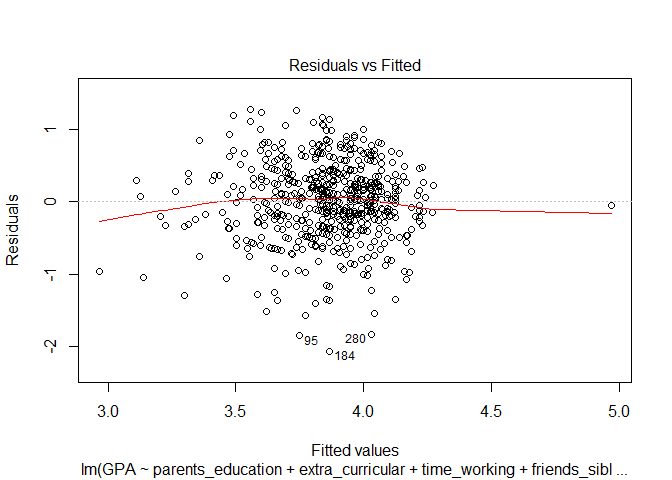

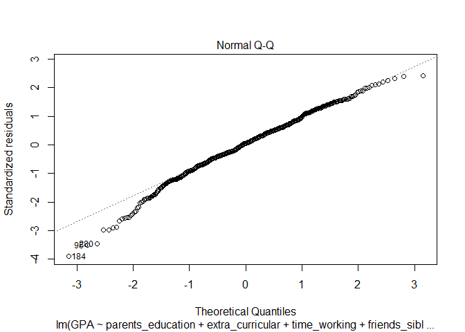

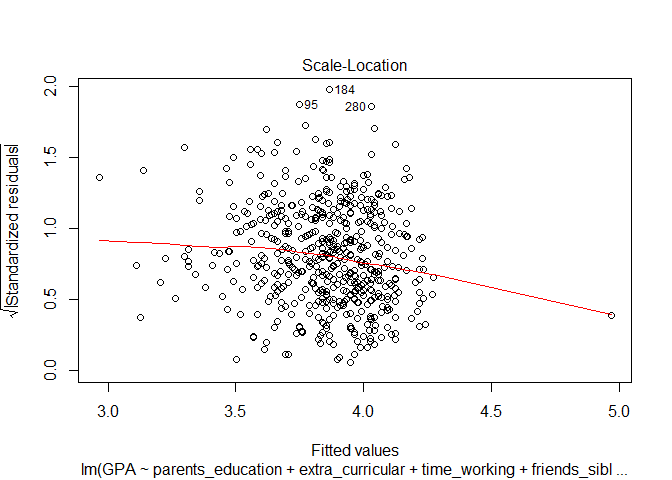

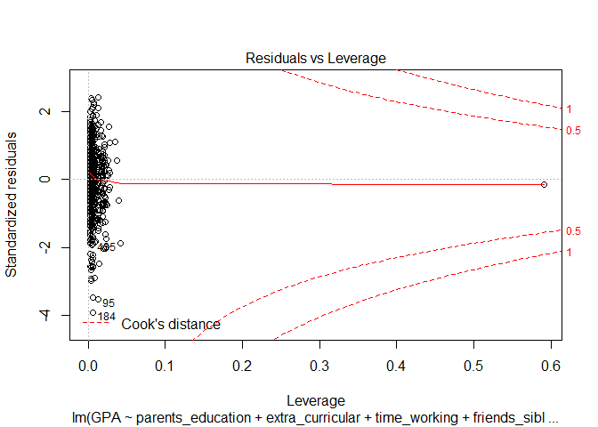

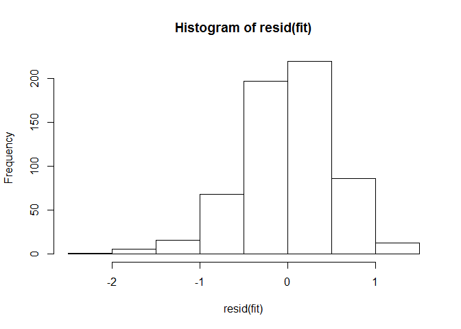

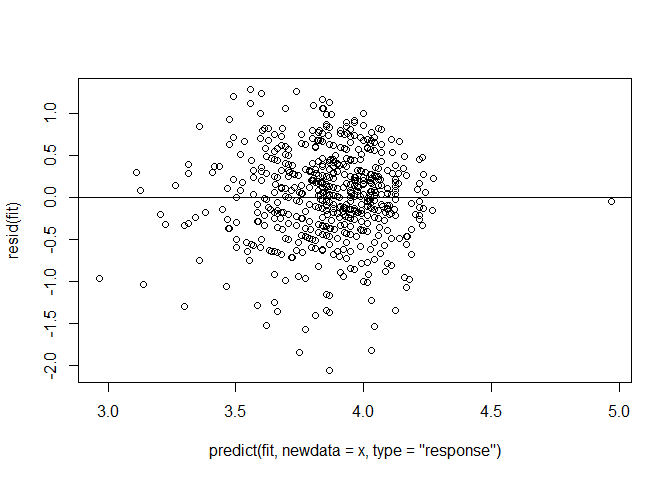

```r
assess_linear_model(fit)
```

The Normal Q-Q plot has tails, Constant Variance is an issue, and the R^2-adjusted of 0.1264 lead us to abandon this model. Based on the standardized residual plot this model should not be used.

```r
# Not good R^2-adjusted = 0.1747
# There are tails on the Normal Q-Q plot however this model could be used, but the low R^2-adjusted should rule out the use of this model.
fit <- x %>% lm(GPA ~ parents_education + extra_curricular + absent + study + meals , data = .)
summary(fit)
```

```
##
## Call:
## lm(formula = GPA ~ parents_education + extra_curricular + absent +
##     study + meals, data = .)
##
## Residuals:
##      Min       1Q   Median       3Q      Max
## -1.95307 -0.29545  0.03288  0.31892  1.33158
##
## Coefficients:
##                     Estimate Std. Error t value Pr(>|t|)
## (Intercept)        2.6707087  0.1373991  19.438  < 2e-16 ***
## parents_education  0.0860538  0.0155544   5.532 4.72e-08 ***
## extra_curricular   0.1364745  0.0267625   5.099 4.57e-07 ***
## absent             0.0006992  0.0060806   0.115    0.908
## study              0.1029866  0.0160626   6.412 2.92e-10 ***
## meals             -0.0063448  0.0040717  -1.558    0.120
## ---
## Signif. codes:  0 '***' 0.001 '**' 0.01 '*' 0.05 '.' 0.1 ' ' 1
##
## Residual standard error: 0.5158 on 600 degrees of freedom
## Multiple R-squared:  0.1815, Adjusted R-squared:  0.1747
## F-statistic: 26.61 on 5 and 600 DF,  p-value: < 2.2e-16
```